# Sesion 14 - Análisis de Correlación Canónica (CCA)

Juan Carlos Martínez-Ovando

Maestría en Ciencia de Datos

Primavera 2019

# 1 Parte 1 - Fundamentos

## 1.1 Objetivo

**El** analisis de correlacion canonica** (`CCA`) es una técnica estadística que estudia la asociación entre dos conjuntos/bloques de variables simultáneamente observadas en el mismo conjunto de individuos o unidades de observación**

Usos de `CCA`:

1. Reducción de dimensionalidad (explicando el comovimiento de los dos bloques a través del comovimiento de combinaciones lineales de dimensiones menores)
2. Exploración de datos (mediante la creacion de `atributos latentes` o `variables canonicas` que explican el comovimiento de un *conjunto de variables originales*)

## 1.2 Notación

Suponemos $\boldsymbol{X}$ y $\boldsymbol{Y}$ como conjuntos de variables de dimensiones $(p\times 1)$ y $(q\times 1)$, respectivamente, con

$$\boldsymbol{X} \sim \text{N}_p(x|\boldsymbol{\mu}_x,\boldsymbol{\Sigma}_x),$$
y
$$\boldsymbol{Y} \sim \text{N}_q(y|\boldsymbol{\mu}_y,\boldsymbol{\Sigma}_y).$$

Si
$$\boldsymbol{\Sigma}_{xy}$$
denota la covarianza entre $\boldsymbol{X}$ y $\boldsymbol{Y}$, entonces,
$$\boldsymbol{Z}=(\boldsymbol{X},\boldsymbol{Y}) \sim \text{N}_{p+q}(z|\boldsymbol{\mu},\boldsymbol{\Sigma}),$$
con
$$\begin{eqnarray}
\boldsymbol{\mu} & = &(\boldsymbol{\mu}_x,\boldsymbol{\mu}_y), \nonumber \\
\boldsymbol{\Sigma} & = & \left(
\begin{array}[c c]
\boldsymbol{\Sigma}_{x} & \boldsymbol{\Sigma}_{xy}\\
\boldsymbol{\Sigma}_{yx} & \boldsymbol{\Sigma}_{y}
\end{array}
\right).
\end{eqnarray}$$

## 1.3 Combinaciones lineales

> **El `CCA` consiste en proyectar $\boldsymbol{X}$ y $\boldsymbol{Y}$ en un espacio de dimension equivalente, y sobre ese espacio definir una estructura de relación entre ambos bloques de datos.**

> **Se define $r$ como la dimensió común de ambas proyecciones.**

De esta manera, para $j=1,\ldots,r$, con
$$r=\min(p,q),$$
se definen las variables unidimensionales
$$U_j = <\boldsymbol{X},a_j>, \\
U_j = <\boldsymbol{Y},b_j>,$$
siendo $(a_j)_{j=1}^{r}$ y $(b_j)_{j=1}^{r}$ dos colecciones de vectores $(p\times 1)$ y $(q\times 1)$ dimensionales, respectivamente.

> **Idea**

Las nuevas variables,
$$\boldsymbol{U}=(U_1,\ldots,U_r),$$
y
$$\boldsymbol{V}=(V_1,\ldots,V_r),$$
resumen la correlacion implícita entre $\boldsymbol{X}$ y $\boldsymbol{Y}$ a través de la especificación cuidadosa de los **vectores de proyeccion**,
$$(a_j,b_j)_{j=1}^{r}.$$

## 1.4 Definición

> La especificación de los vectores de proyección
> $$(a_j,b_j)_{j=1}^{r},$$
> se realiza de la siguiente forma:

Para $j=1$ se eligen $a_1$ y $b_1$ tales que

- $\rho(U_1,V_1)=\frac{a_1'\Sigma_{xy}b_1}{(a_1\Sigma_x a_1)^{1/2}(b_1\Sigma_y b_1)^{1/2}}$ sea **máxima**
- (sujeto a que) $var(U_1)=1$ y $var(V_1)=1.$

Para $j\geq 2$ se eligen $a_j$ y $b_j$ tales que

- $\rho(U_j,V_j)=\frac{a_j'\Sigma_{xy}b_j}{(a_j\Sigma_x a_j)^{1/2}(b_j\Sigma_y b_j)^{1/2}}$ sea **máxima**
- (sujeto a que) $var(U_j)=1$ y$var(V_j)=1$, y
- $\rho\left((U_j,V_j),(U_l,V_l)\right)=0$ para todo $l<j$.

**Nota: `CCA` es en esencia un problema de optimizacion cuadratica con restricciones anidadas. (Semejante a una interpretación del `PCA`).**

## 1.5 Solución matricial

> **De manera semejante a `PCA`, el `CCA` puede calcularse matricialmente.**

Resulta ser que las $j$-esimas **variables canonicas** estan dadas por
$$U_j = e_{xj}'\boldsymbol{\Sigma}_x^{-1/2}\boldsymbol{X},$$
y
$$V_j=e_{xj}'\boldsymbol{\Sigma}_y^{-1/2}\boldsymbol{X},$$
donde $e_{xj}$ y $e_{yj}$ son vectores $(p\times 1)$ y $(q\times 1)$ dimensionales, respectivamente, que corresponden a los $j$-ésimos **eigenvectore de las matrices**,
$$\boldsymbol{\Sigma}_{x}^{-1/2}\boldsymbol{\Sigma}_{xy}\boldsymbol{\Sigma}_y^{-1}\boldsymbol{\Sigma}_{yx}\boldsymbol{\Sigma}_{x}^{-1/2},$$
y
$$\boldsymbol{\Sigma}_{y}^{-1/2}\boldsymbol{\Sigma}_{yx}\boldsymbol{\Sigma}_x^{-1}\boldsymbol{\Sigma}_{xy}\boldsymbol{\Sigma}_{y}^{-1/2},$$
respectivamente.

**Nota:** El $j$-esimo eigenvector $\rho_j$ de las matrices arriba corresponde con la **correlacion entre las variables canonicas** correspondientes, $U_j$ y $V_j$.

## 1.6 Variables canonicas

> **A través de las proyecciones canónicas, es posible recuperar las variables proyectadas como** *variables latentes canónicas*.

Las nuevas **variables canonicas** se definen como
$$\boldsymbol{U} = \boldsymbol{A}'\boldsymbol{X}$$
y
$$\boldsymbol{V} = \boldsymbol{B}'\boldsymbol{Y},$$
ambas de dimension $(r\times 1)$, donde
$$\boldsymbol{A}=(a_1',\ldots,a_r')$$
y
$$\boldsymbol{B}=(b_1',\ldots,b_r'),$$
son ambas matrices de dimensiones $(r\times p)$ y $(r\times q)$, respectivamente.

- Los renglones en las matrices $\boldsymbol{A}$ y $\boldsymbol{B}$ miden la contriución de cada dimension a las *variables canonicas correspondientes*.

> Estas matrices corresponden a los `eigenvectores` de las matrices de covarianzas tranformadas descritas anteriormente.

## 1.7 Comentarios

- De manera semejante a `PCA`, el modelo `CCA` se define como `muestral` (`SCCA`), `poblacional` (`PCCA`) o `inferencial` (`ICCA`).
- El modelo, de manera semejante a `FA`, se define localmente *observacion-a-observación*.
- Al construirse sobre **matrices de covarianzas** resulta ser sensible a la forma de modelar la media por observaciones.
- El modelo `CCA` presupone que las matrices de covarianzas son de `rango completo` (no es tan drástico este supuesto, es implícito en `PCA` tambi’n).
- Si los datos están estandarizados en escala para que tengan varianza 1 *dimensión-a-dimensión*, entonces `CCA` estaría implementado sobre matrices de correlaciones.

## 1.8 Paquetes

En `R` les recomiendo dos paquetes:

- `CCA`, que en realidad implementa `SCCA`
- `CCAGFA`, que en implementa `ICCA` con el enfoque bayesiano, junto con otras extensiones interesantes.

```
if(!require('CCA')){install.packages("CCA")}
suppressMessages(library("CCA"))

if(!require('CCAGFA')){install.packages("CCAGFA")}
suppressMessages(library("CCAGFA"))
```

# 2 Parte 2 - Ilustración

## 2.1 Datos

Los datos que analizamos corresponden a 600 registros de estudiantes relacionados con sus habilidades academicas, capacidades emocionales y actitud.

- **actitud** - `control`, `concepto`, `motivacion`
- **habiliades** - `lectura`, `escritura`, `matematicas`, `ciencias`
- **intrinsecas** - `genero`

## 2.2 Objetivo

> **Resumir como estas variables en bloque se relacionan entre si.**

## 2.3 Información

```r
datos <- read.csv("est46114_s14_ccadata.csv", header = TRUE)
colnames(datos)
```

```
## [1] "control"     "concepto"    "motivacion"  "lectura"     "escritura"
## [6] "matematicas" "ciencia"     "genero"
```

```r
head(datos)
```

```
##   control concepto motivacion lectura escritura matematicas ciencia genero
## 1   -0.84    -0.24       1.00    54.8      64.5        44.5    52.6      1
## 2   -0.38    -0.47       0.67    62.7      43.7        44.7    52.6      1
## 3    0.89     0.59       0.67    60.6      56.7        70.5    58.0      0
## 4    0.71     0.28       0.67    62.7      56.7        54.7    58.0      0
## 5   -0.64     0.03       1.00    41.6      46.3        38.4    36.3      1
## 6    1.11     0.90       0.33    62.7      64.5        61.4    58.0      1
```

```r
dim(datos)
```

```
## [1] 600   8
```

La estructura de dependencia muestral de estos datos es de la siguiente forma:

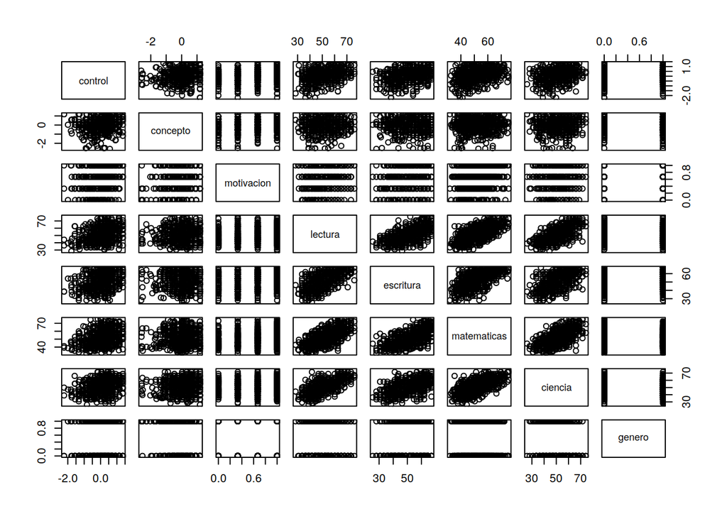

```r
plot(datos)
```

Considerando el conjunto de `datos`, se requiere especificar dos conjuntos de variables. En este ejemplo, dividiremos los `datos` en dos bloques:

### 2.3.1 Bloque A) `aptitud`+/-`genero`

Correspondiente a las mediciones:

- `control`
- `concepto`
- `moitivacion`

```r
aptitud <- datos[,c("control","concepto","motivacion" )]
summary(aptitud)
```

```
##     control            concepto           motivacion
##  Min.   :-2.23000   Min.   :-2.620000   Min.   :0.0000
##  1st Qu.:-0.37250   1st Qu.:-0.300000   1st Qu.:0.3300
##  Median : 0.21000   Median : 0.030000   Median :0.6700
##  Mean   : 0.09653   Mean   : 0.004917   Mean   :0.6608
##  3rd Qu.: 0.51000   3rd Qu.: 0.440000   3rd Qu.:1.0000
##  Max.   : 1.36000   Max.   : 1.190000   Max.   :1.0000
```

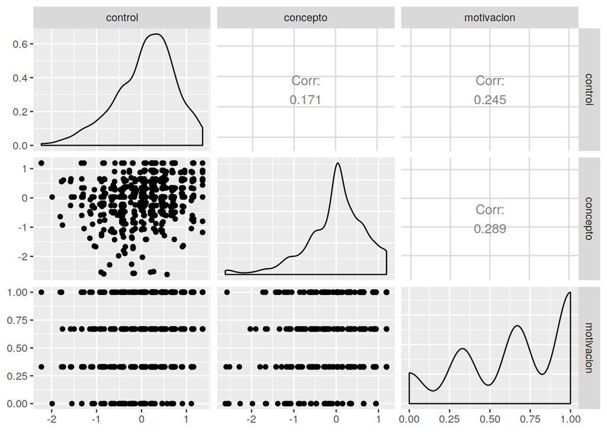

```r
ggpairs(aptitud)
```

### 2.3.2 Bloque B) `habilidades`

Considerando las mediciones:

- `lectura`
- `escritura`
- `matematicas`
- `ciencia`

```r
habilidades <- datos[,c("lectura","escritura","matematicas","ciencia")]
summary(habilidades)
```

```
##     lectura       escritura      matematicas       ciencia
##  Min.   :28.3   Min.   :25.50   Min.   :31.80   Min.   :26.00
##  1st Qu.:44.2   1st Qu.:44.30   1st Qu.:44.50   1st Qu.:44.40
##  Median :52.1   Median :54.10   Median :51.30   Median :52.60
##  Mean   :51.9   Mean   :52.38   Mean   :51.85   Mean   :51.76
##  3rd Qu.:60.1   3rd Qu.:59.90   3rd Qu.:58.38   3rd Qu.:58.65
##  Max.   :76.0   Max.   :67.10   Max.   :75.50   Max.   :74.20
```

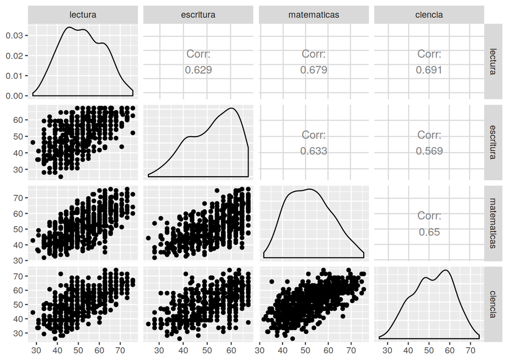

```r
ggpairs(habilidades)
```

## 2.4 Correlaciones

A continuación calcularmos las matrices de correlaciones $\boldsymbol{\rho}$ para los datos:

```r
mat.corr <- matcor(aptitud, habilidades)
```

**Aptitud**

```
##              control  concepto motivacion
## control    1.0000000 0.1711878  0.2451323
## concepto   0.1711878 1.0000000  0.2885707
## motivacion 0.2451323 0.2885707  1.0000000
```

**Habilidades**

```
##               lectura escritura matematicas   ciencia
## lectura     1.0000000 0.6285909   0.6792757 0.6906929
## escritura   0.6285909 1.0000000   0.6326664 0.5691498
## matematicas 0.6792757 0.6326664   1.0000000 0.6495261
## ciencia     0.6906929 0.5691498   0.6495261 1.0000000
```

**Aptitud** + **Habilidades**

```
##               control   concepto motivacion    lectura  escritura
## control     1.0000000 0.17118778  0.2451323 0.37356505 0.35887684
## concepto    0.1711878 1.00000000  0.2885707 0.06065584 0.01944856
## motivacion  0.2451323 0.28857075  1.0000000 0.21060992 0.25424818
## lectura     0.3735650 0.06065584  0.2106099 1.00000000 0.62859089
## escritura   0.3588768 0.01944856  0.2542482 0.62859089 1.00000000
## matematicas 0.3372690 0.05359770  0.1950135 0.67927568 0.63266640
## ciencia     0.3246269 0.06982633  0.1156695 0.69069291 0.56914983
##             matematicas    ciencia
## control       0.3372690 0.32462694
## concepto      0.0535977 0.06982633
## motivacion    0.1950135 0.11566948
## lectura       0.6792757 0.69069291
## escritura     0.6326664 0.56914983
## matematicas   1.0000000 0.64952612
## ciencia       0.6495261 1.00000000
```

## 2.5 Analisis `SCCA`

```r
datos.cc <- cc(aptitud, habilidades)
```

*Nota: Revisen la documentacion de la funcion `cc` y la libreria `CCA` en general.*

```
summary(datos.cc)
```

**Correlacion canonica**

Hasta `3` coeficientes de correlacion canonica… *Recuerdan?*

[output not shown]

**Coeficientes de cargas del** `SCCA`

- **Aptitud**

```
##         control   concepto motivacion
## [1,] -1.2501212  0.2367331  -1.249143
## [2,]  0.7659633  0.8421110  -2.635962
## [3,]  0.4966529 -1.2051225  -1.093508
```

- **Habilidades**

```
##          lectura   escritura matematicas     ciencia
## [1,] -0.04404713 -0.05508884 -0.01940110 0.003797762
## [2,] -0.00159291 -0.09041460 -0.00295546 0.124208983
## [3,] -0.08833171  0.09612884 -0.08782244 0.088495188
```

*Como interpretamos estas cifras???*

**Vectores canonicos del** `SCCA`

```r
datos.cc.coef <- comput(aptitud, habilidades, datos.cc)
head(datos.cc.coef$xscores)
```

```
##            [,1]       [,2]        [,3]
## [1,]  0.6891325 -1.8176278 -0.54085901
## [2,]  0.4718454 -0.7891026  0.32563729
## [3,] -0.8648714  1.0763085 -0.32104343
## [4,] -0.7132368  0.6773807 -0.03685296
## [5,]  0.5030262 -1.4370652 -0.76691152
## [6,] -0.6418020  2.4021021 -0.21357490
```

```r
head(datos.cc.coef$yscores)
```

```
##            [,1]       [,2]        [,3]
## [1,] -0.6493103 -0.9743633  1.62806499
## [2,]  0.1446851  0.8930853 -1.08679997
## [3,] -0.9590113  0.3155183 -1.43957322
## [4,] -0.7449730  0.3588694 -0.23747534
## [5,]  0.9911719 -1.3143692  0.13774392
## [6,] -1.3046533 -0.3661661 -0.07608067
```

Los datos en este apartado corresponden a las *correlaciones* entre las *variables originales* y las *variables canonicas*.

**Loadings `CCA`**

- **Aptitud**

```
##          control    concepto motivacion
## [1,] -0.91428518 -0.09996773 -0.5853255
## [2,]  0.39365803  0.42130826 -0.6061228
## [3,]  0.09547756 -0.90139104 -0.5385250
```

- **Habilidades**

```
##           lectura    escritura  matematicas      ciencia
## [1,] -0.393057063 -0.406314050 -0.357145182 -0.309872933
## [2,]  0.037559216 -0.033887663  0.028821253  0.103653541
## [3,] -0.006144737  0.007646605 -0.006381333  0.005348465
```

**Significacia del `SCCA`**

> Las dimensiones canonicas (o variables canonicas), son *variables latentes* cuya interpretación es análoga a la de los *factores latentes* obtenidos en el `AF`.

> **Pregunta:** ¿Cuáles de esas *variables canónicas* son estadísticamente significativas?

```r
ev <- (1 - datos.cc$cor^2)
n <- dim(aptitud)[1]
p <- length(habilidades)
q <- length(aptitud)
k <- min(p, q)
m <- n - 3/2 - (p + q)/2
w <- rev(cumprod(rev(ev)))
d1 <- d2 <- f <- vector("numeric", k)
for (i in 1:k) {
    s <- sqrt((p^2 * q^2 - 4)/(p^2 + q^2 - 5))
    si <- 1/s
    d1[i] <- p * q
    d2[i] <- m * s - p * q/2 + 1
    r <- (1 - w[i]^si)/w[i]^si
    f[i] <- r * d2[i]/d1[i]
    p <- p - 1
    q <- q - 1
}
```

```r
pv <- pf(f, d1, d2, lower.tail = FALSE)
dmat <- cbind(WilksL = w, F = f, df1 = d1, df2 = d2, p = pv)
dmat
```

```
##         WilksL         F df1      df2            p
## [1,] 0.7814670 12.773540  12 1569.222 2.630211e-25
## [2,] 0.9759865  2.421026   6 1188.000 2.487710e-02
## [3,] 0.9994936       NaN   2      NaN          NaN
```

**Significacia del `CCA`**

> Ajustes por variaciones en escala en los datos originales.
- **Aptitud**

La matriz diagonal de coeficientes canónicos estandarizados de `aptitud` dada por `sd`.

```r
s1 <- diag(sqrt(diag(cov(aptitud))))
s1 %*% datos.cc$xcoef
```

```
##            [,1]       [,2]       [,3]
## [1,] -0.8379311  0.5134098  0.3328964
## [2,]  0.1670182  0.5941199 -0.8502290
## [3,] -0.4281181 -0.9034217 -0.3747775
```

- **Habilidades**

La matriz diagonal estandarizada de los coeficientes `habiliades` academicas con base en `sd`.

```r
s2 <- diag(sqrt(diag(cov(habilidades))))
s2 %*% datos.cc$ycoef
```

```
##             [,1]        [,2]       [,3]
## [1,] -0.44500741 -0.01609314 -0.8924138
## [2,] -0.53581915 -0.87941356  0.9349929
## [3,] -0.18265622 -0.02782487 -0.8268251
## [4,]  0.03686176  1.20559459  0.8589501
```

# 3 Temas avanzados

- Implicaciones de emplear variables `estandarizadas` o `no estandarizadas`
- Implicaciones de realizar `CCA` con variables discretas o categóricas
- Incorporacion de la **incertidumbre epistémica** asociada con el aprendizaje de $\boldsymbol{\Sigma}_x$, $\boldsymbol{\Sigma}_y$ y $\boldsymbol{\Sigma}_{xy}$ **especialmente**, como en el caso de `PCA`
- Anticipar/predecir la **correlacion canonica** entre un conjunto de variables futuras $\boldsymbol{X}^{f}$ y $\boldsymbol{Y}^{f}$, con base en el aprendizaje realizado.
- *Escalabilidad* de la solución
- `CCA` para más de dos conjuntos de variables simúltaneamente.
- `CCA` no lineal (`CCA Funcional`)

# 4 Siguiente sesión

En la siguiente sesión:

- Discutiremos el uso de `PCA`, `FA` y `CCA` para realizar predicción analítica
- Revisaremos pseudo código con ilustraciones

# 5 Lecturas

## 5.1 Complementarias

- Izenman, *Modern Multivariate Statistical Techniques*, Seccion 7.3
- `CCAGFA` vignettes
- `CCA` vignettes

## 5.2 Extendidadas

- Adrover y Donato *A robust predictive approach for canonical correlation analysis* `est46114_s14_complemento1.pdf`
- Bonner y Liu *Canonical Correlation, an Approximation, and the Prediction of Protein Abundance* `est46114_s14_complemento2.pdf`